# Extensão e Sociologia Rural

Sociologia Rural no Brasil  
Atores, Temas, Objetos de Estudo e Teorias

Luiz Diego Vidal Santos

## Visão Geral

### Tópicos Principais

- 1 O que é Sociologia Rural
- 2 Consolidação no Brasil
- 3 Atores: pesquisadores e grupos sociais
- 4 Temas: agricultura familiar, questão agrária
- 5 Novas ruralidades e desenvolvimento sustentável

**Objetivo Central**

Compreender os fundamentos da sociologia rural brasileira, seus atores, temas centrais e teorias que orientam o estudo das dinâmicas sociais no campo.

## O QUE É SOCIOLOGIA RURAL?

**Definição:**

A sociologia rural, enquanto campo da ciência social, dedica-se ao estudo das **dinâmicas coletivas** - processos, artefatos, ideias ou produtos - que mediam as relações entre seres humanos no campo e a intersecção com o urbano.

**Objetos de estudo:**

- Particularidades das comunidades agrárias
- Relações urbano-rurais
- Capitalismo e questão fundiária
- Relações de trabalho
- Cotidiano social do meio rural

## A SOCIOLOGIA RURAL E O COTIDIANO

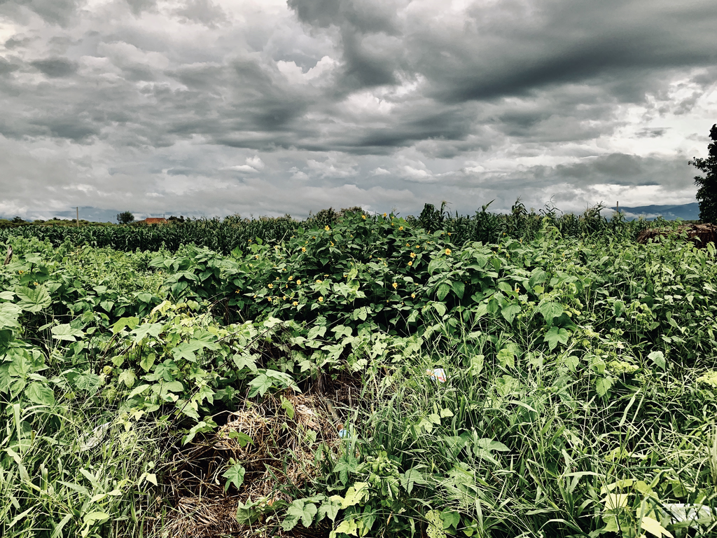

Paisagem agrícola na Caatinga nordestina (CC-BY-SA, Wikimedia)

Como José de Souza Martins (2003) argumenta:

> *“O cotidiano é uma dimensão fundamental da vida social, e está intrinsecamente relacionado com o processo de desenvolvimento.”*

A Sociologia Rural não apenas analisa as transformações econômicas e tecnológicas, mas também se aprofunda nas **questões culturais, identitárias** e nas **formas de resistência e adaptação** das comunidades rurais.

## CONSOLIDAÇÃO NO BRASIL

**Década de 1950:** Consolidação a partir da **USP**, com influência das teorias de Marx e Weber.

**Década de 1960:** Primeiros programas de pós-graduação:

- UFRGS
- USP-Piracicaba (ESALQ)
- UFV
- UFRPE

**Pós-1964:** A sociologia rural se estabelece como campo disciplinar chave, com foco em **comunicação agrícola** e **modernização do campo**.

## ATORES: PESQUISADORES

| Pesquisador | Contribuição principal |
| --- | --- |
| **Pitirim Sorokin e Carle Zimmerman** | Interações sociais rurais |
| **José de Souza Martins** | Questão agrária, movimentos sociais, campesinato |
| **Afrânio Garcia Jr.** | Categorias de análise, modernização agrícola |
| **Maria Nazareth Wanderley** | Resistência e resiliência dos pequenos agricultores |
| **Sergio Schneider** | Pluriatividade, sistemas agroalimentares |
| **Maria Ignez S. Paulilo e Anita Brumer** | Mulheres no campo, gênero |

## ATORES: PESQUISADORES (cont.)

**Outros pesquisadores relevantes (não sociólogos):**

- **Alexander Chayanov** - Economia camponesa
- **Ignacy Sachs** - Desenvolvimento sustentável
- **Ricardo Abramovay** - Capitalismo agrário
- **Amartya Sen** - Desenvolvimento como liberdade

## ATORES: GRUPOS SOCIAIS NO CAMPO

Os movimentos sociais no campo representam uma **força vital** na configuração das relações sociais, políticas e econômicas em áreas rurais.

Emergem como respostas a diversas formas de **injustiça social** (Abramovay et al., 2010):

- Concentração fundiária
- Exploração laboral
- Degradação ambiental

**Destaques:**

- Ligas Camponesas no Nordeste
- **MST** - maior movimento social livre do Brasil

## ATORES: AGENTES PÚBLICOS E TERCEIRO SETOR

**Órgãos públicos e coletivos:**

- Sindicatos e confederações sindicais (CONTAG)
- Associações rurais
- Cooperativas (caráter misto)

**Terceiro setor:**

- Igreja Católica - Teoria da Libertação
- Comissões Pastorais da Terra (CPT)
- Confederação Nacional dos Bispos do Brasil (CNBB)
- Associações Cristãs de Base (ACB)

## TEMAS: AGRICULTURA FAMILIAR E CAMPESINATO

A agricultura familiar é **vital** para garantir a segurança alimentar e a proteção ambiental.

Anita Brumer (1993):

> *“A agricultura camponesa e de base familiar nasceu no Brasil sob o signo da precariedade - jurídica, econômica, social.”*

**Características da agricultura familiar:**

- Ligação socioafetiva e consanguínea
- Não se limita ao autoconsumo (Lei de Chayanov)
- Não é necessariamente aversa ao risco (Lei de Lipton)
- Pluriatividade evidente na sobrevivência do sistema

## TEMAS: QUESTÃO AGRÁRIA

A questão agrária brasileira é **multifacetada**, englobando:

- Reforma agrária
- Assistência técnica
- Desenvolvimento rural
- Segurança alimentar

**Autores-chave:** Graziano da Silva (1980), José Eli de Veiga (1991), Zander Navarro (2011)

Envolve a análise das **relações sociais no campo** e das **dinâmicas econômicas agrícolas**, incluindo produção, consumo, tecnologias e reforma agrária.

## TEMAS: RELAÇÕES DE TRABALHO E RENDA

**Precarização do trabalho:**

José de Souza Martins (2000): o trabalho rural, frequentemente à margem da lei, expõe trabalhadores a **vulnerabilidades sociológicas**, incluindo trabalho análogo à escravidão.

**Envelhecimento da população rural:**

- Êxodo juvenil para áreas urbanas
- Pressão sobre sistemas de produção
- Ameaça à continuidade do modo de vida rural

## TEMAS: NOVAS RURALIDADES

O conceito de “novas ruralidades” refere-se às **mudanças significativas** no mundo rural nas últimas décadas:

- Da fazenda à empresa moderna e exportadora (Graziano da Silva, 1998)
- Pluralidade de novas atividades no campo
- Questão indígena e povos originários
- Mulheres no campo como cidadãs de iguais direitos
- **Pluriatividade rural** (Schneider, 2015)

## TEMAS: MODERNIZAÇÃO E GÊNERO

**Modernização do campo:**

A revolução verde e a transição para a agricultura industrial resultaram em discrepâncias: monoculturas intensivas *vs.* marginalização da agricultura familiar.

**Empoderamento da mulher no campo:**

- Mulheres rurais enfrentam **desafios estruturais** agravados por desigualdades de gênero (Brumer, 2003; Paulilo, 2016)
- Acesso limitado à propriedade de terra
- Preferência por herdeiros homens

## TEMAS: DESENVOLVIMENTO RURAL SUSTENTÁVEL

Autores como Veiga, Schneider, Sachs e Sen ressaltam a importância de:

- **Liberdade e autonomia** no desenvolvimento rural
- **Conexão ambiental** e sustentabilidade

Ignacy Sachs propõe um modelo baseado em:

- Uso de **biomassa, biodiversidade e biotecnologia sustentável**
- Múltiplas dimensões: sociais, culturais, ecológicas, psicológicas
- Soluções que demandam conhecimento e mão de obra, mas econômicas em capital

## REFERÊNCIAS

- Brasil. Lei 4.504/64 - Estatuto da Terra (1964)
- Brumer, A. Estudos agrários no Brasil (2006)
- Graziano da Silva, J. O que é questão agrária (1980)
- Kageyama, A. A. A questão agrária extrapola fronteiras (1993)
- Martins, J. S. A sociabilidade do homem simples (2003)
- Navarro, Z. Desenvolvimento rural no Brasil (2001)
- Schneider, S. Situando o desenvolvimento rural no Brasil (2010)
- Veiga, J. E. O Desenvolvimento Agrícola (1991)

Obrigado!

Luiz Diego Vidal Santos

Universidade Federal de Sergipe (UFS)